# Project 1

Cassie Chou

2024-09-13

## Background

```r
library("tidyverse")
library("here")
library("forcats")

if (!dir.exists(here("data"))) {
    dir.create(here("data"))
}

# saves data only once (not each time you knit a R Markdown)
if (!file.exists(here("data", "chocolate.RDS"))) {
    url_csv <- "https://raw.githubusercontent.com/rfordatascience/tidytuesday/master/data/2022/2022-01-18/chocolate.csv"
    chocolate <- readr::read_csv(url_csv)

    # save the file to RDS objects
    saveRDS(chocolate, file = here("data", "chocolate.RDS"))
}

chocolate <- readRDS(here("data", "chocolate.RDS"))
as_tibble(chocolate)
```

```
## # A tibble: 2,530 × 10
##      ref company_manufacturer company_location review_date
##    <dbl> <chr>                <chr>                  <dbl>
##  1  2454 5150                 U.S.A.                  2019
##  2  2458 5150                 U.S.A.                  2019
##  3  2454 5150                 U.S.A.                  2019
##  4  2542 5150                 U.S.A.                  2021
##  5  2546 5150                 U.S.A.                  2021
##  6  2546 5150                 U.S.A.                  2021
##  7  2542 5150                 U.S.A.                  2021
##  8   797 A. Morin             France                  2012
##  9   797 A. Morin             France                  2012
## 10  1011 A. Morin             France                  2013
## # ℹ 2,520 more rows
## # ℹ 6 more variables: country_of_bean_origin <chr>,
## #   specific_bean_origin_or_bar_name <chr>, cocoa_percent <chr>,
## #   ingredients <chr>, most_memorable_characteristics <chr>, rating <dbl>
```

```r
glimpse(chocolate)
```

```
## Rows: 2,530
## Columns: 10
## $ ref                              <dbl> 2454, 2458, 2454, 2542, 2546, 2546, 2…
## $ company_manufacturer             <chr> "5150", "5150", "5150", "5150", "5150…
## $ company_location                 <chr> "U.S.A.", "U.S.A.", "U.S.A.", "U.S.A.…
## $ review_date                      <dbl> 2019, 2019, 2019, 2021, 2021, 2021, 2…
## $ country_of_bean_origin           <chr> "Tanzania", "Dominican Republic", "Ma…
## $ specific_bean_origin_or_bar_name <chr> "Kokoa Kamili, batch 1", "Zorzal, bat…
## $ cocoa_percent                    <chr> "76%", "76%", "76%", "68%", "72%", "8…
## $ ingredients                      <chr> "3- B,S,C", "3- B,S,C", "3- B,S,C", "…
## $ most_memorable_characteristics   <chr> "rich cocoa, fatty, bready", "cocoa, …
## $ rating                           <dbl> 3.25, 3.50, 3.75, 3.00, 3.00, 3.25, 3…
```

## Part 1

### 1

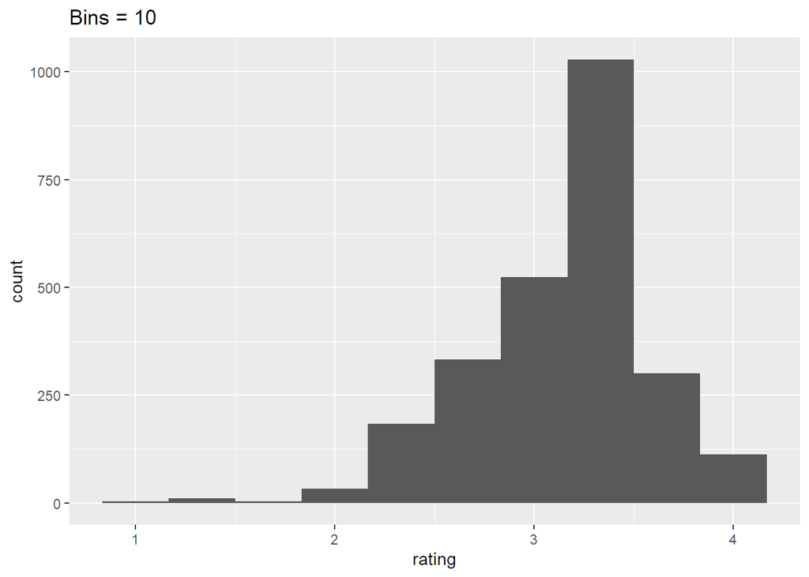

```r
ggplot(data = chocolate, aes(x = rating)) + geom_histogram(bins = 10) + ggtitle("Bins = 10")
```

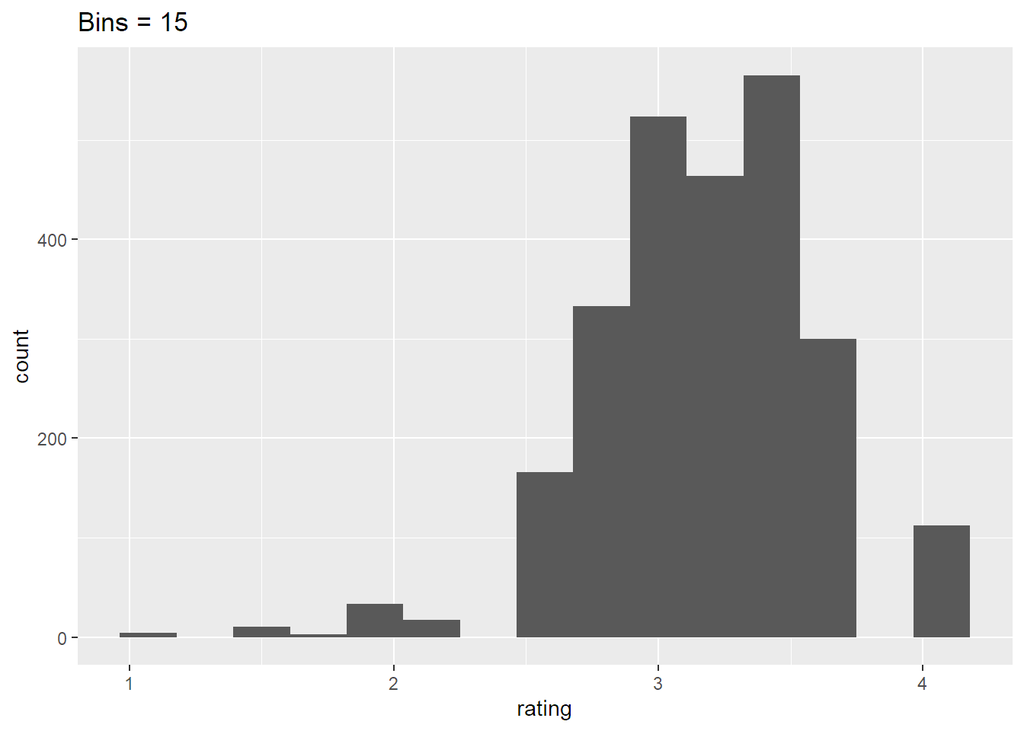

```r
ggplot(data = chocolate, aes(x = rating)) + geom_histogram(bins = 15) + ggtitle("Bins = 15")
```

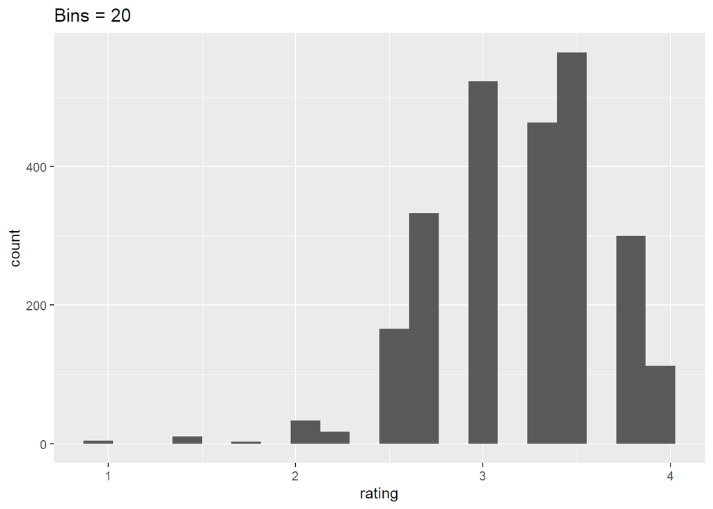

```r
ggplot(data = chocolate, aes(x = rating)) + geom_histogram(bins = 20) + ggtitle("Bins = 20")
```

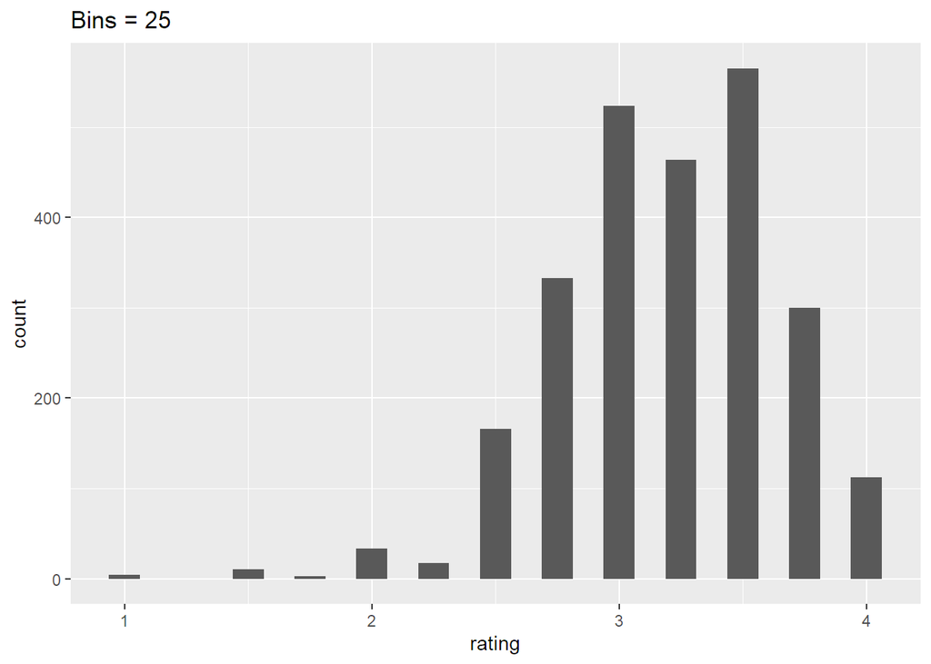

```r
ggplot(data = chocolate, aes(x = rating)) + geom_histogram(bins = 25) + ggtitle("Bins = 25")
```

The best plot has 15 bins – I chose this plot because it captures more specific variation than the oversimplified plot with 10 bins, but does not introduce too many gaps in the data, like the plot with 20 bins or 25 bins. I captures the overall shape of the data without oversimplifying it.

### 2

The number of ratings from each country is shown in the tibble below.

```r
countries_count <- count(chocolate, country_of_bean_origin)

print(countries_count, n = 63)
```

```
## # A tibble: 62 × 2
##    country_of_bean_origin     n
##    <chr>                  <int>
##  1 Australia                  3
##  2 Belize                    76
##  3 Blend                    156
##  4 Bolivia                   80
##  5 Brazil                    78
##  6 Burma                      1
##  7 Cameroon                   3
##  8 China                      1
##  9 Colombia                  79
## 10 Congo                     11
## 11 Costa Rica                43
## 12 Cuba                      12
```

[output cut: 50 more lines]

### 3

```r
chocolate %>% filter(country_of_bean_origin == "Ecuador") %>% select(rating) %>% summarise(mean = mean(rating), sd = sd(rating), total = n())
```

```
## # A tibble: 1 × 3
##    mean    sd total
##   <dbl> <dbl> <int>
## 1  3.16 0.512   219
```

### 4

```r
chocolate %>% filter(country_of_bean_origin == "Ecuador") %>% group_by(company_location) %>% summarise(avg = mean(rating))%>% arrange(desc(avg))
```

```
## # A tibble: 25 × 2
##    company_location   avg
##    <chr>            <dbl>
##  1 Australia         3.81
##  2 Switzerland       3.75
##  3 New Zealand       3.62
##  4 Hungary           3.5
##  5 Israel            3.5
##  6 Netherlands       3.5
##  7 Singapore         3.5
##  8 South Korea       3.33
##  9 Canada            3.28
## 10 U.S.A.            3.26
## # ℹ 15 more rows
```

The location that makes the best chocolates is Australia.

### 5

```r
chocolate %>% group_by(country_of_bean_origin) %>% summarise(avg = mean(rating)) %>% arrange(desc(avg))
```

```
## # A tibble: 62 × 2
##    country_of_bean_origin   avg
##    <chr>                  <dbl>
##  1 Tobago                  3.62
##  2 China                   3.5
##  3 Sao Tome & Principe     3.5
##  4 Solomon Islands         3.45
##  5 Congo                   3.32
##  6 Thailand                3.3
##  7 Cuba                    3.29
##  8 Vietnam                 3.29
##  9 Papua New Guinea        3.28
## 10 Madagascar              3.27
## # ℹ 52 more rows
```

Tobago, China, and Sao Tome & Principe are the 3 countries with the highest ratings on average.

### 6

```r
chocolate %>% group_by(country_of_bean_origin) %>% filter(n() >= 10) %>% summarise(avg = mean(rating)) %>% arrange(desc(avg))
```

```
## # A tibble: 35 × 2
##    country_of_bean_origin   avg
##    <chr>                  <dbl>
##  1 Solomon Islands         3.45
##  2 Congo                   3.32
##  3 Cuba                    3.29
##  4 Vietnam                 3.29
##  5 Papua New Guinea        3.28
##  6 Madagascar              3.27
##  7 Haiti                   3.27
##  8 Brazil                  3.26
##  9 Guatemala               3.26
## 10 Nicaragua               3.26
## # ℹ 25 more rows
```

Now, the countries with the highest ratings are the Solomon Islands, Congo, and Cuba.

### 7

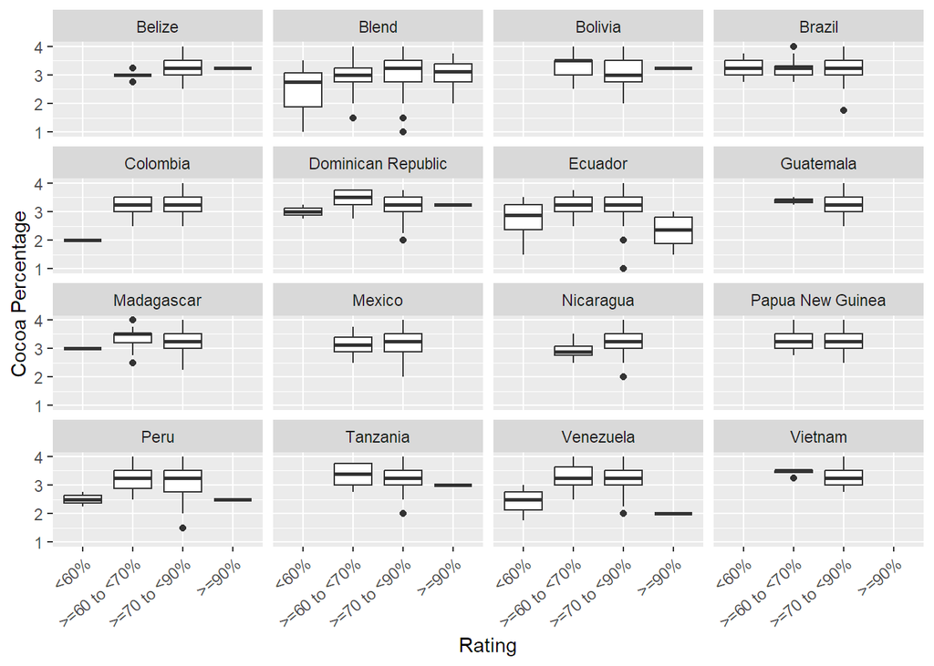

```r
chocolate_above50 <- chocolate %>% group_by(country_of_bean_origin) %>% filter(n() >= 50)
chocolate_groups <- chocolate_above50 %>% mutate(cocoa_percent_num = as.numeric(substr(cocoa_percent, 1,2))) %>% mutate(grouped_cocoa = case_when(cocoa_percent_num < 60 ~ "<60%", cocoa_percent_num >= 60 & cocoa_percent_num < 70 ~ ">=60 to <70%", cocoa_percent_num >= 70 & cocoa_percent_num < 90 ~ ">=70 to <90%", cocoa_percent_num >= 90 ~ ">=90%"))

chocolate_groups$grouped_cocoa <- fct_relevel(chocolate_groups$grouped_cocoa,"<60%", ">=60 to <70%", ">=70 to <90%", ">=90%")

ggplot(data = chocolate_groups, aes(x = grouped_cocoa, y = rating)) + geom_boxplot() +
    facet_wrap(~country_of_bean_origin) + xlab("Rating") + ylab("Cocoa Percentage") + theme(axis.text.x = element_text(angle = 40, hjust = 1))
```

Overall, it seems the 60% < chocolate percent < 70% category has the highest rating, though there is some disagreement between the countries – take Nicaragua and Mexico, for example. Some countries rate 70-90% cocoa chocolate higher.

## Part 2

```r
library(gapminder)

chocolate_continents <- chocolate %>% filter(country_of_bean_origin != "Blend") %>% left_join(gapminder %>% select(country, continent), by = c("country_of_bean_origin" = "country"), multiple = "first") %>% group_by(country_of_bean_origin) %>% filter(n() >= 10)

chocolate_continents[is.na(chocolate_continents$continent), ] %>% group_by(country_of_bean_origin) %>% summarise(total = n())
```

```
## # A tibble: 11 × 2
##    country_of_bean_origin total
##    <chr>                  <int>
##  1 Belize                    76
##  2 Congo                     11
##  3 Fiji                      16
##  4 Grenada                   19
##  5 Papua New Guinea          50
##  6 Sao Tome                  14
##  7 Solomon Islands           10
##  8 St. Lucia                 10
##  9 Trinidad                  42
## 10 U.S.A.                    33
## 11 Vanuatu                   13
```

```r
americas <- c("Belize", "Grenada", "Trinidad", "U.S.A.", "St. Lucia")
africa <- c("Congo", "Sao Tome")
oceania <- c("Fiji", "Papua New Guinea", "Vanuatu", "Solomon Islands")

chocolate_continents$continent[chocolate_continents$country_of_bean_origin %in% americas] <- "Americas"
chocolate_continents$continent[chocolate_continents$country_of_bean_origin %in% africa] <- "Africa"
chocolate_continents$continent[chocolate_continents$country_of_bean_origin %in% oceania] <- "Oceania"

chocolate_continents
```

```
## # A tibble: 2,292 × 11
## # Groups:   country_of_bean_origin [34]
##      ref company_manufacturer company_location review_date
##    <dbl> <chr>                <chr>                  <dbl>
##  1  2454 5150                 U.S.A.                  2019
##  2  2458 5150                 U.S.A.                  2019
##  3  2454 5150                 U.S.A.                  2019
##  4  2542 5150                 U.S.A.                  2021
##  5  2546 5150                 U.S.A.                  2021
##  6  2546 5150                 U.S.A.                  2021
##  7  2542 5150                 U.S.A.                  2021
##  8   797 A. Morin             France                  2012
##  9   797 A. Morin             France                  2012
## 10  1015 A. Morin             France                  2013
## # ℹ 2,282 more rows
## # ℹ 7 more variables: country_of_bean_origin <chr>,
## #   specific_bean_origin_or_bar_name <chr>, cocoa_percent <chr>,
## #   ingredients <chr>, most_memorable_characteristics <chr>, rating <dbl>,
## #   continent <fct>
```

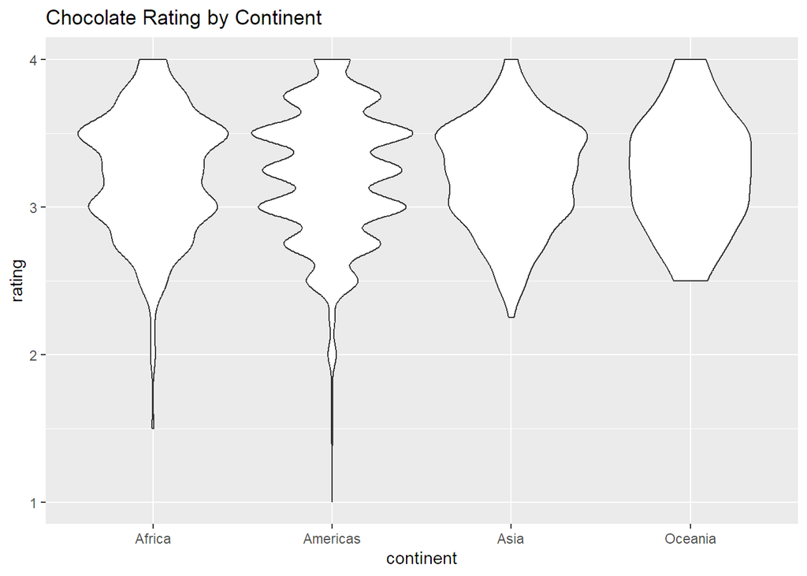

```r
ggplot(chocolate_continents, aes(x = continent, y = rating)) + geom_violin() + labs(title = "Chocolate Rating by Continent")
```

## Part 3

```r
choco_ing <- chocolate %>% mutate(
  beans = ifelse(str_detect(ingredients, "B") & !is.na(ingredients), 1, 0),
  sugar = ifelse(str_detect(ingredients, "S,|S$") & !is.na(ingredients), 1, 0),
  cocoa_butter = ifelse(str_detect(ingredients, "C") & !is.na(ingredients), 1, 0),
  vanilla = ifelse(str_detect(ingredients, "V"), 1, 0) & !is.na(ingredients),
  letchin = ifelse(str_detect(ingredients, "L"), 1, 0) & !is.na(ingredients),
  salt = ifelse(str_detect(ingredients, "Sa") & !is.na(ingredients), 1, 0))

choco_ing_char <- choco_ing %>% mutate(
  char_cocoa = ifelse(str_detect(most_memorable_characteristics, "cocoa"), 1, 0),
  char_sweet = ifelse(str_detect(most_memorable_characteristics, "sweet"), 1, 0),
  char_nutty = ifelse(str_detect(most_memorable_characteristics, "nutty"), 1, 0),
  char_creamy = ifelse(str_detect(most_memorable_characteristics, "creamy"), 1, 0),
  char_roasty = ifelse(str_detect(most_memorable_characteristics, "roasty"), 1, 0),
  char_earthy = ifelse(str_detect(most_memorable_characteristics, "earthy"), 1, 0))

suppressWarnings(ing_char_means <- choco_ing_char %>% group_by(review_date) %>% select(c(beans, sugar, cocoa_butter, vanilla, letchin, salt, char_cocoa, char_sweet, char_nutty, char_creamy, char_roasty, char_earthy)) %>% summarise_each(funs(mean)))
ing_char_means
```

```
## # A tibble: 16 × 13
##    review_date beans sugar cocoa_butter vanilla letchin    salt char_cocoa
##          <dbl> <dbl> <dbl>        <dbl>   <dbl>   <dbl>   <dbl>      <dbl>
##  1        2006 0.968 0.968        0.903  0.694   0.694  0           0.210
##  2        2007 0.945 0.945        0.767  0.548   0.384  0           0.342
##  3        2008 0.913 0.902        0.75   0.359   0.511  0           0.109
##  4        2009 0.919 0.919        0.772  0.325   0.341  0           0.146
##  5        2010 0.855 0.845        0.709  0.227   0.391  0.00909     0.218
##  6        2011 0.939 0.914        0.693  0.160   0.160  0.0491      0.172
##  7        2012 0.928 0.814        0.675  0.186   0.124  0.0722      0.0876
##  8        2013 0.967 0.951        0.776  0.208   0.295  0.0164      0.175
##  9        2014 0.984 0.943        0.644  0.0688  0.121  0.0324      0.0607
## 10        2015 0.986 0.937        0.546  0.0599  0.120  0           0.127
## 11        2016 0.982 0.954        0.594  0.0507  0.106  0.00922     0.0922
## 12        2017 0.981 0.971        0.562  0.0286  0.133  0.00952     0.133
## 13        2018 0.987 0.925        0.596  0.0614  0.132  0           0.180
## 14        2019 1     0.969        0.679  0.0259  0.202  0           0.259
## 15        2020 1     1            0.568  0.0370  0.0247 0           0.284
## 16        2021 1     0.994        0.646  0.0114  0.08   0           0.297
## # ℹ 5 more variables: char_sweet <dbl>, char_nutty <dbl>, char_creamy <dbl>,
## #   char_roasty <dbl>, char_earthy <dbl>
```

```r
tidy_ing_char <- pivot_longer(ing_char_means, cols = c(-1), names_to = "feature", values_to = "mean_score")

tidy_ing_char
```

```
## # A tibble: 192 × 3
##    review_date feature      mean_score
##          <dbl> <chr>             <dbl>
##  1        2006 beans            0.968
##  2        2006 sugar            0.968
##  3        2006 cocoa_butter     0.903
##  4        2006 vanilla          0.694
##  5        2006 letchin          0.694
##  6        2006 salt             0
##  7        2006 char_cocoa       0.210
##  8        2006 char_sweet       0.161
##  9        2006 char_nutty       0.0323
## 10        2006 char_creamy      0.242
## # ℹ 182 more rows
```

## Part 4

```r
library(extrafont)
```

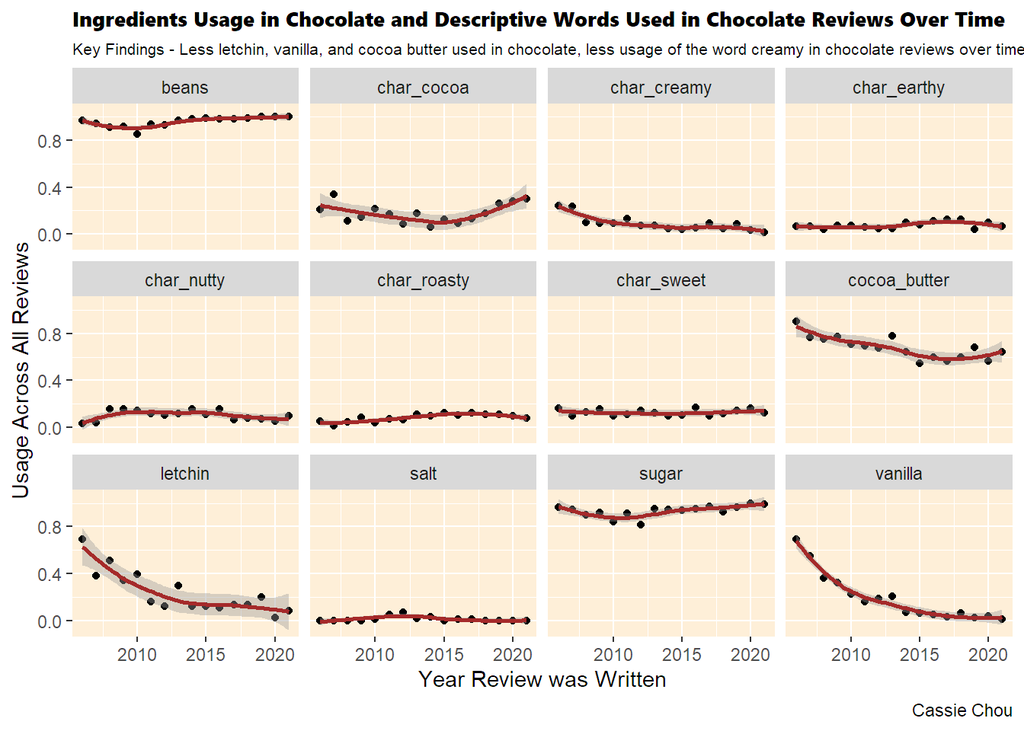

```r
ggplot(tidy_ing_char, aes(x = review_date, y = mean_score)) +
  geom_point() + geom_smooth(color = "brown") + facet_wrap(~feature) +
  labs(title = "Ingredients Usage in Chocolate and Descriptive Words Used in Chocolate Reviews Over Time",
       subtitle = "Key Findings - Less letchin, vanilla, and cocoa butter used in chocolate, less usage of the word creamy in chocolate reviews over time",
       caption = "Cassie Chou") +
  xlab("Year Review was Written") +
  ylab("Usage Across All Reviews") +
  theme(plot.title = element_text(family = "Segoe UI Black", size = 10), plot.subtitle = element_text(size = 8), panel.background = element_rect(fill = "#feefd8"))
```

## Part 5

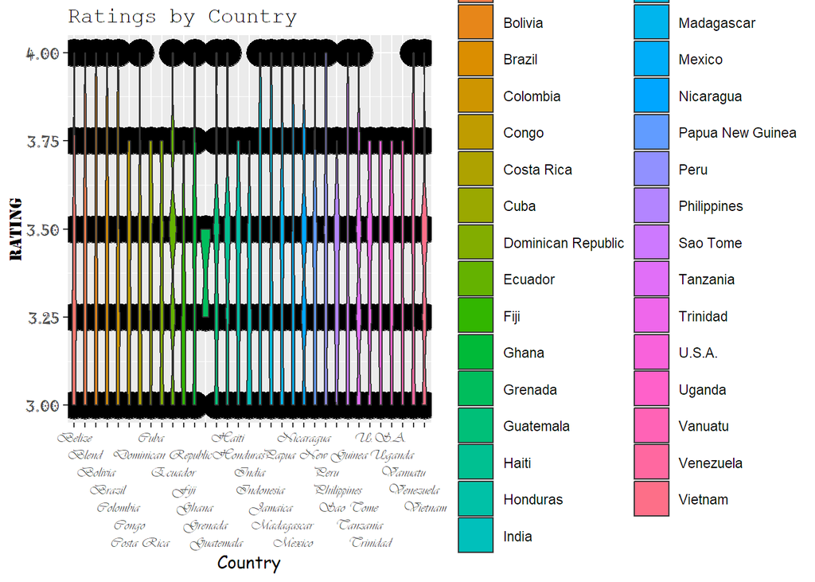

```r
chocolate %>% group_by(country_of_bean_origin) %>% filter(n() > 10) %>% ggplot(aes(x = country_of_bean_origin, y = rating, fill = country_of_bean_origin)) +
  geom_point(size = 8) +
  geom_violin() +
  scale_x_discrete(guide = guide_axis(n.dodge=7)) +
  xlab("Country") + ylab("Rating") +
  labs(title = "Ratings by Country") +
  ylim(3, 4) +
  theme(plot.title= element_text(family = "mono"),
        axis.title.x  = element_text(family = "Comic Sans MS"),
        axis.title.y  = element_text(family = "Stencil"),
        axis.text.x   = element_text(family = "Vivaldi"),
        axis.text.y   = element_text(family = "Jokerman"))
```

1. Added fill colors based on the country of the bean’s origin that mean nothing. For other plots, this could be helpful if we used color to show related bars/color-code plots.
2. Added scatterplot overlay, which is useless because reviews are discrete values – 1, 1.5, 2, 2.5, etc. This could be helpful in the future if we had continuous values.
3. Made country plot labels 7 rows deep, which makes it hard to tell which countries match which violin plot. This function could be helpful for other charts where the x-labels would otherwise overlap.
4. Changed the X-Label to “Country”, which is not informative of what the country stands for. Left Y-Label as rating, which is not informative of what we’re rating. Added title that just says “Rating by Country”, which again, is not informative of what this plot actually shows. In the future, all of these labels will help viewers understand and interpret my graph.
5. Made the y-limit from 3 to 4, which cuts out half of our data, and only shows half of the violin plots. Changing the y-limits in the future could be helpful for data with outliers.
6. Changed the size of the scatterplot dots to be obnoxiously large. Changing the size of scatterplot points could be helpful in the future for visualization – especially if we have a lot of points that are very near to each other.
7. Changed the fonts of all the axes and titles to be unmatching and confusing. In the future, it might be helpful to change fonts for the labels or titles.

## Part 6

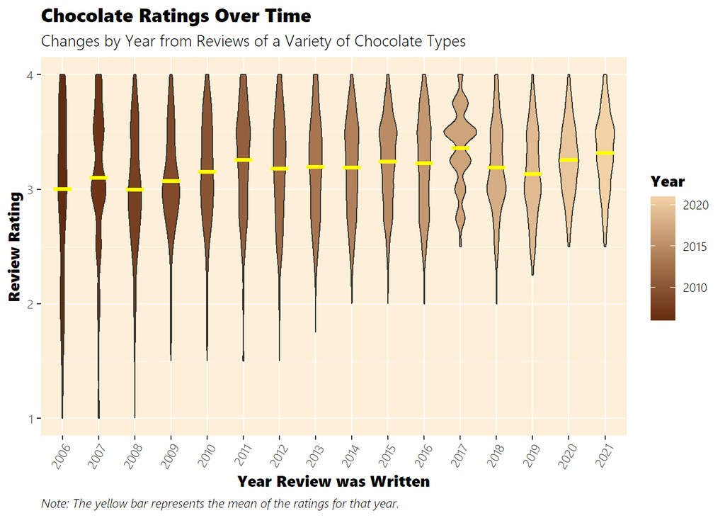

```r
library(ggthemes)

chocolate %>%
    ggplot(aes(
        x = as.factor(review_date),
        y = rating,
        fill = review_date
    )) +
    geom_violin() +
    labs(title = "Chocolate Ratings Over Time", subtitle = "Changes by Year from Reviews of a Variety of Chocolate Types", caption = "Note: The yellow bar represents the mean of the ratings for that year.") +
    xlab("Year Review was Written") + ylab("Review Rating") +
    labs(fill = "Year") +
    theme(plot.title = element_text(family = "Segoe UI Black"),
          plot.subtitle = element_text(family = "Segoe UI Semilight"),
        axis.title.x = element_text(family = "Segoe UI Black"),
        axis.title.y = element_text(family = "Segoe UI Black"),
        legend.title = element_text(family = "Segoe UI Black"),
        axis.text.x = element_text(family = "Segoe UI Semilight", angle = 60, hjust = 1),
        axis.text.y = element_text(family = "Segoe UI Semilight"),
        legend.text = element_text(family = "Segoe UI Semilight"),
        plot.caption =  element_text(family = "Segoe UI Semilight", hjust = 0, face = "italic"),
        panel.background = element_rect(fill = "#feefd8")) +
    scale_fill_gradient(low="#642b0e", high="#f3d2a6") +
    stat_summary(fun = "mean",
               geom = "crossbar",
               width = 0.5,
               colour = "yellow")
```

1. Added a title and subtitle to better describe the data.
2. Changed x-axis and y-axis labels to better describe the x and y variables. Similarly relabeled the legend title.
3. Changed fonts of all labels to emphasize the x and y axis titles and the main title.
4. Changed color of plot background and individual plot fills to match the chocolate theme!
5. Added bars on each violin plot that represent the mean of the reviews for that year to help visualize how reviews have changed over time.
6. Added caption to describe the mean labels (the yellow bars) and adjusted its themeing and position.
7. Adjusted x-axis year text labels to be angled to better match each plot.